# Part 1 of Final Project

Chloe Seeborg

March 11, 2024

## Describing the Data

### Question 1

The dataset that I am choosing to work with is the Anthromes dataset. It is a global land use dataset that tracks how humans have been shaping the land for the past 12,000 years. The dataset is derived from HYDE 3.2, which documents human populations and land use over time. One bias with HYDE 3.2 is that it is known to underestimate early agricultural land use. To avoid having to deal with this, I can focus my analysis on more recent history instead of prehistory.

The data is in the format of an equal-area Discrete Global Grid system (~96 square kilometer hexagonal “DGG cells”). The authors chose this format because it overcomes spatial biases present in previous versions of the dataset, which was formatted with non equal-area 5 arc-minute grid cells (this is also the format of the HYDE data, which it is based upon.

Citation: Ellis, Erle; Nicolas Gauthier, 2023, “Anthromes 12K DGG v1 shapefile”, https://doi.org/10.7910/DVN/SZFCPX, Harvard Dataverse, V1; anthromes_12k_dgg_v1_complete.zip [fileName]

I am also using the R package and the accompanying instructions later in this document, so I will cite it here.

Citation: Gauthier, Nicolas (2021). Anthromes 12K DGG (V1) analysis code and R research compendium. Online at Harvard Dataverse, https://doi.org/10.7910/DVN/6FWPZ9

### Question 2

My data isn’t necessarily not tidy, there are just 75 columns in the data that correspond to time periods ranging from 10,000 BC to 2017 AD. So, I may want to use dplyr to filter out the columns that I’m not interested in, which is most of them. I am going to create a new shapefile with only one time period column (2000AD) and also rename the column so it doesn’t start with a number. The creation of the shapefile is commented out so that the document can knit properly.

```r
anthromes <- read_sf("anthromes/an12_dgg_complete.shp")
selected_cols <- anthromes %>%
  select(id, land_ar, pot_veg, pot_vll, regn_nm, `2000AD`, geometry) %>%
  rename(AD2000 = `2000AD`)
# st_write(selected_cols, "AD2000_anthromes.shp")
```

### Question 3

This is a rich dataset, and two possible research questions are…

1. Where are there hotspots of undeveloped land today?
2. How has land use changed over time?

### Question 4

To answer research question 1, I would use a cluster analysis.

To answer research question 2, I could calculate Landscape Metrics such as a Landscape Division Index and an Aggregation Index to see how the distribution of different land cover types have varied across time.

## Exploring the Data

### Question 5

Visualize the center and spread of key variables. Describe the distribution of each variable.

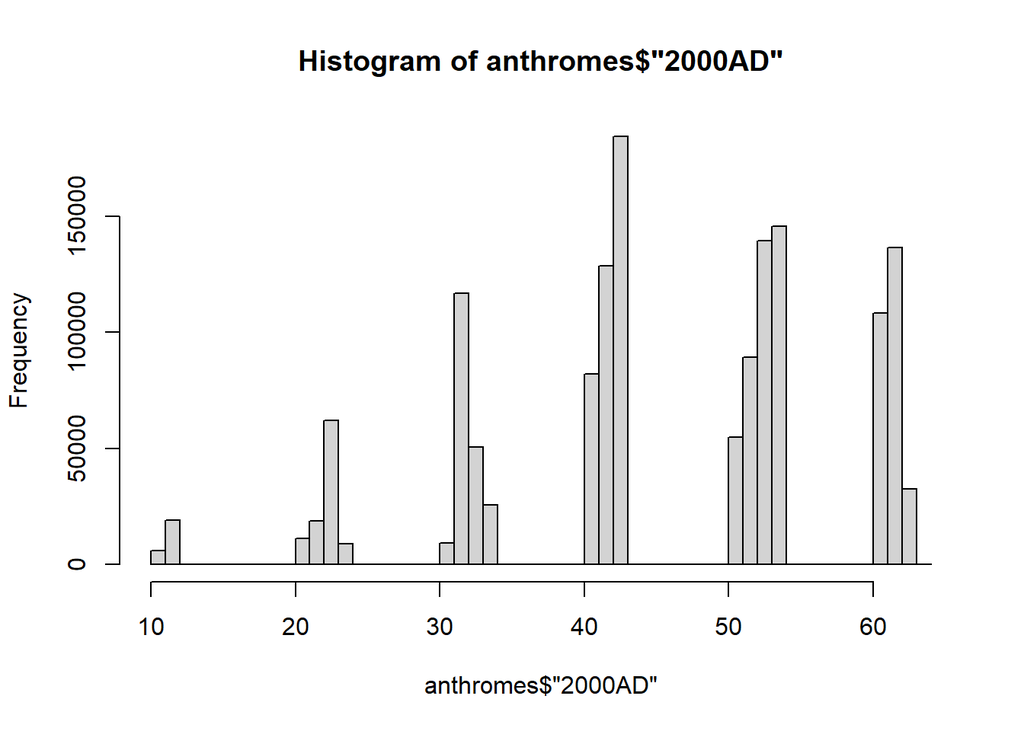

```r
hist(anthromes$"2000AD", breaks = seq(min(anthromes$`2000AD`)-1, max(anthromes$`2000AD`)+1, by = 1))
```

```r
table(anthromes$"2000AD")
```

```
##
##     11     12     21     22     23     24     31     32     33     34     41
##   6020  18980  11112  18683  62103   8943   9177 116793  50628  25623  81945
##     42     43     51     52     53     54     61     62     63
## 128607 184131  54932  89071 139474 145700 108306 136323  32473
```

```r
table(anthromes$regn_nm)
```

```
##
##        Africa          Asia       Eurasia        Europe Latin America
##        253480        204509        257505         43116        217834
##     Near East North America       Oceania
##        131320        229297         91963
```

In the year 2000AD, the most common land use was 43 (Remote Rangelands), with 184,131 cells. To see all of the land use categories and the frequency of land use for each country see the plot in question 7 which visualizes it very well.

### Question 6

Develop a strategy to identify outliers. Query data to see if there are any shared characteristics of outlier observations.

I can’t figure out how to find outliers with land use data :(

### Question 7

Group the data. Compute and visualize summary statistics for each group.

```r
grouped <- selected_cols %>%
  select(-geometry) %>%
  st_drop_geometry() %>%
  group_by(regn_nm, AD2000) %>%
  summarize(count = n(), .groups = 'keep') %>%
  arrange(regn_nm, desc(count)) %>%
  print()
```

```
## # A tibble: 153 × 3
## # Groups:   regn_nm, AD2000 [153]
##    regn_nm AD2000 count
##    <chr>    <dbl> <int>
##  1 Africa      54 53347
##  2 Africa      42 48614
##  3 Africa      41 40267
##  4 Africa      32 24508
##  5 Africa      43 22916
##  6 Africa      52 16826
##  7 Africa      62 13040
##  8 Africa      23  9856
##  9 Africa      51  8701
## 10 Africa      53  6821
## # ℹ 143 more rows
```

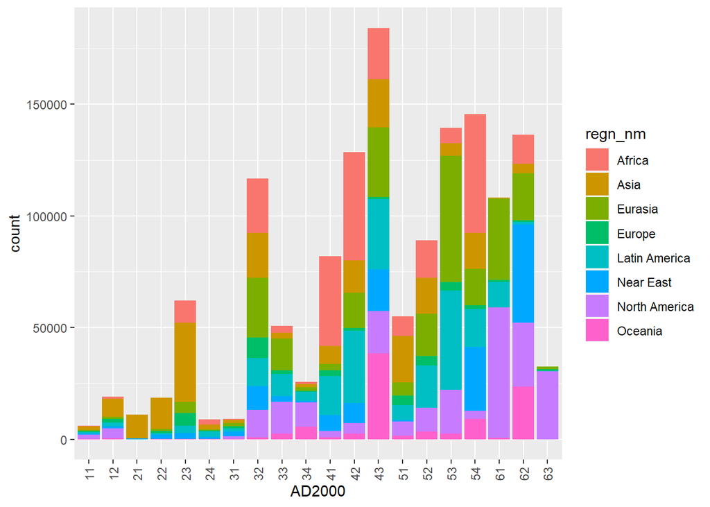

```r
plot_data <- selected_cols
plot_data$AD2000 <- factor(plot_data$AD2000, ordered = TRUE)
ggplot(plot_data, aes(x = AD2000, fill = regn_nm)) +
  geom_bar() +
  theme(axis.text.x = element_text(angle = 90, vjust = 0.5, hjust = 1))
```

Africa: Most common is 54 – Inhabited Drylands – with 53,347 cells.

Asia: Most common is 23 – Rainfed Villages – with 35,591 cells.

Eurasia: Most common is 53 – Remote Woodlands – with 56,360 cells.

Europe: Most common is 32 – Residential Rainfed Croplands – with 9,336 cells.

Latin America: Most common is 53 – Remote Woodlands – with 44,566 cells.

Near East (Middle East): Most common is 62 – Wild Drylands – with 44,019 cells.

North America: Most common is 61 – Wild Woodlands – with 58,446 cells.

Oceania: Most common is 43 – Remote Rangelands – with 38,554 cells.

### Question 8

Compute and visualize correlation between two variables.

```r
contingency_table <- table(selected_cols$regn_nm, selected_cols$AD2000)
chi_squared_test <- chisq.test(contingency_table)
print(chi_squared_test)
```

```
##
##  Pearson's Chi-squared test
##
## data:  contingency_table
## X-squared = 1208987, df = 133, p-value < 2.2e-16
```

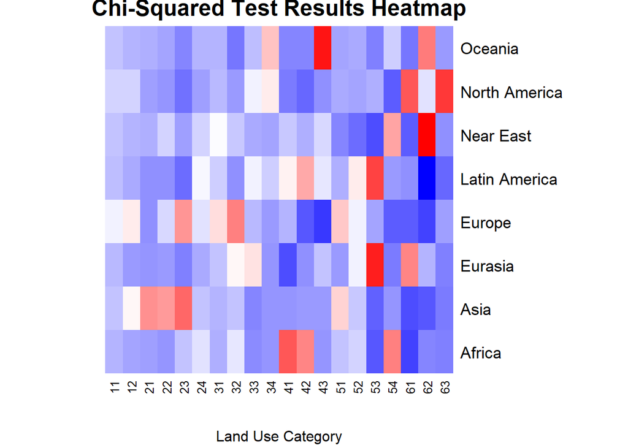

```r
residuals <- chi_squared_test$residuals
heatmap(residuals,
        Rowv = NA,
        Colv = NA,
        col = colorRampPalette(c("blue", "white", "red"))(100),
        main = "Chi-Squared Test Results Heatmap",
        xlab = "Land Use Category")
```

### Question 9

Create an exploratory and multivariate visualization of your dataset based on one or more of your research questions.

To address my research question about how land use changes over time, I am going to recreate the bar chart from question 7 but for different time periods.

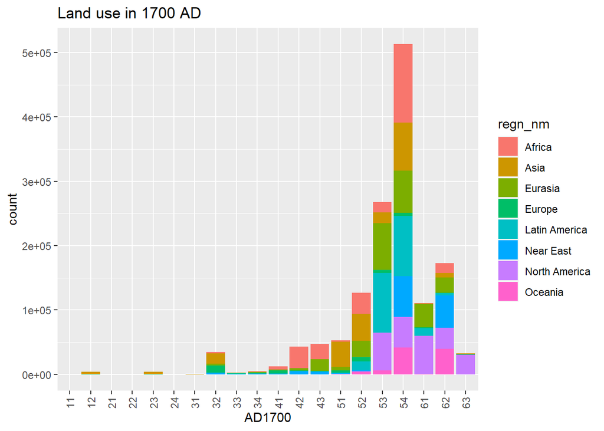

```r
plot_AD1700 <- anthromes %>%
  select(id, land_ar, pot_veg, pot_vll, regn_nm, `1700AD`, geometry) %>%
  rename(AD1700 = `1700AD`)
plot_AD1700$AD1700 <- factor(plot_AD1700$AD1700, ordered = TRUE)
ggplot(plot_AD1700, aes(x = AD1700, fill = regn_nm)) +
  geom_bar() +
  ggtitle("Land use in 1700 AD") +
  theme(axis.text.x = element_text(angle = 90, vjust = 0.5, hjust = 1))
```

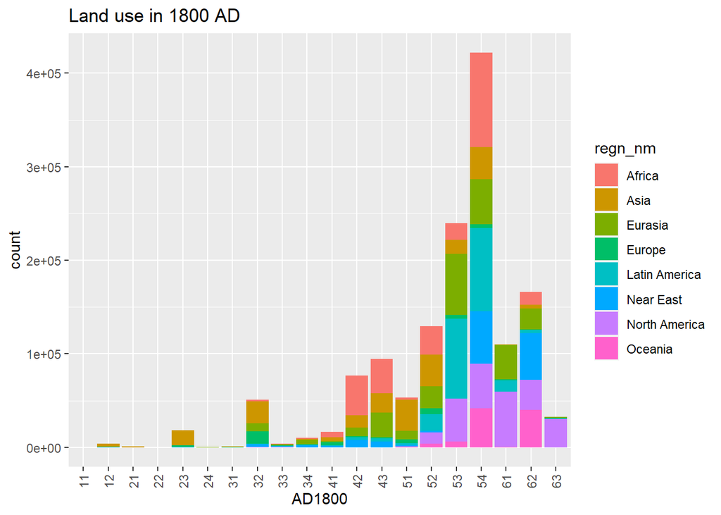

```r
plot_AD1800 <- anthromes %>%
  select(id, land_ar, pot_veg, pot_vll, regn_nm, `1800AD`, geometry) %>%
  rename(AD1800 = `1800AD`)
plot_AD1800$AD1800 <- factor(plot_AD1800$AD1800, ordered = TRUE)
ggplot(plot_AD1800, aes(x = AD1800, fill = regn_nm)) +
  geom_bar() +
  ggtitle("Land use in 1800 AD") +
  theme(axis.text.x = element_text(angle = 90, vjust = 0.5, hjust = 1))
```

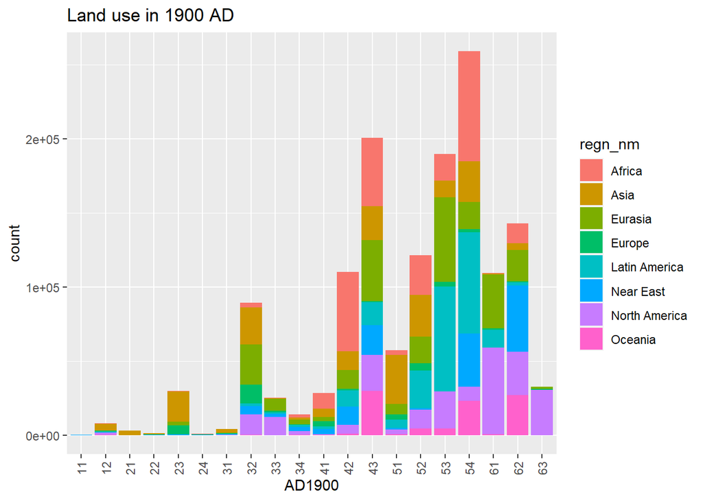

```r
plot_AD1900 <- anthromes %>%
  select(id, land_ar, pot_veg, pot_vll, regn_nm, `1900AD`, geometry) %>%
  rename(AD1900 = `1900AD`)
plot_AD1900$AD1900 <- factor(plot_AD1900$AD1900, ordered = TRUE)
ggplot(plot_AD1900, aes(x = AD1900, fill = regn_nm)) +
  geom_bar() +
  ggtitle("Land use in 1900 AD") +
  theme(axis.text.x = element_text(angle = 90, vjust = 0.5, hjust = 1))
```